# Loan Approval

# Visualizing NUMERIC FEATURES RELATIONSHIP(CORRELATION)

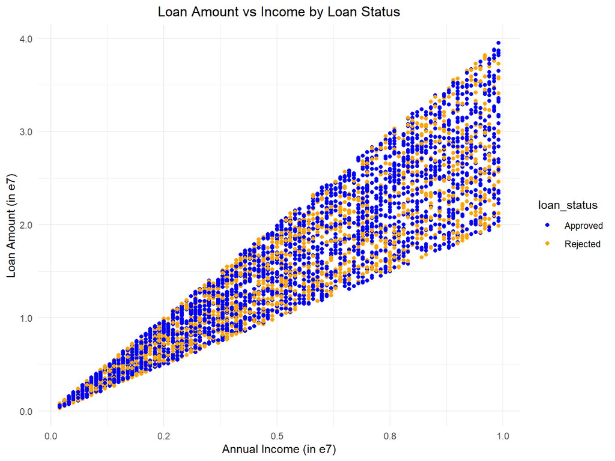

-Applicants with high income tends to take apply for high loan amounts

[figure not shown]

-Applicants with more balance in their accounts tend to buy high value luxury items

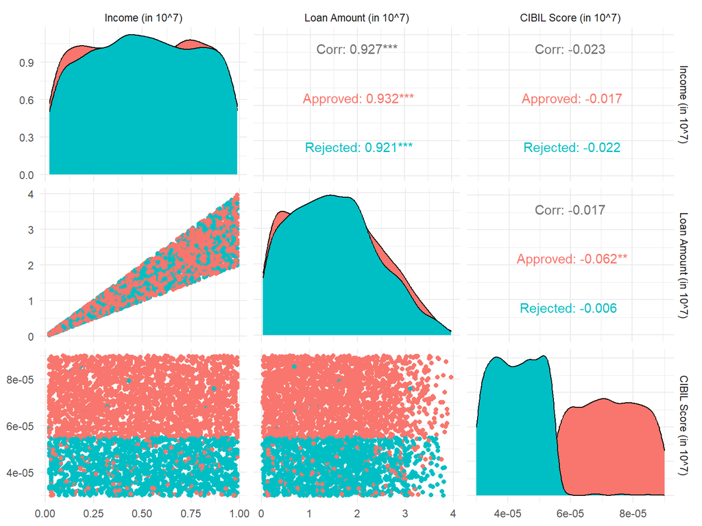

-No relation between cibil score and income annum and loan amount

[figure not shown]

- As the cibil_score increases the Approval of loan status has been seen
- INDICATING applicants having a good credit history and loan replayment tends to have higher chances of loan approval